# Ensemble Forecast and Uncertainty Analysis

2025-04-25

# Setup

```r
library(tidyverse)
library(ecoforecastR)
library(rjags)
library(lubridate)

load("cleaned_data.RData")
load("combined_factors_noburnin.RData") #loads in params and predict
load("precip_ens_forecast.RData") # loads in ensemble precipitation forecast
```

## Forecast Start Date

The forecast starts on the first day after the last NEON chlorophyll-a measurement was released. This is typically yesterday, as in the day before the forecast is being made. The forecast then runs for 30 days, as is specified in the NEON forecasting challenge.

```r
NT = 30 # forecast length
hist_dates <- as_date(cleaned_data$datetime)
forecast_dates <- seq.Date(from = tail(hist_dates, 1) + 1, by = "day", length.out = NT)
dates <- c(hist_dates, forecast_dates)
```

On the day this was knitted (and so this forecast was generated), the forecast begins on 2025-04-24.

# Driver Forecasts

## Precipitation

For precipitation flux, we are using a 30 member ensemble forecast from NOAA GEFS. Note due to the timing of the first day of the forecast, observed NOAA meteorological data is typically available for that first day. So the driver value is observed for the first day of the forecast and then is taken from the NOAA ensemble forecast for the remaining 29 days.

The ensemble driver values and their mean are plotted below.

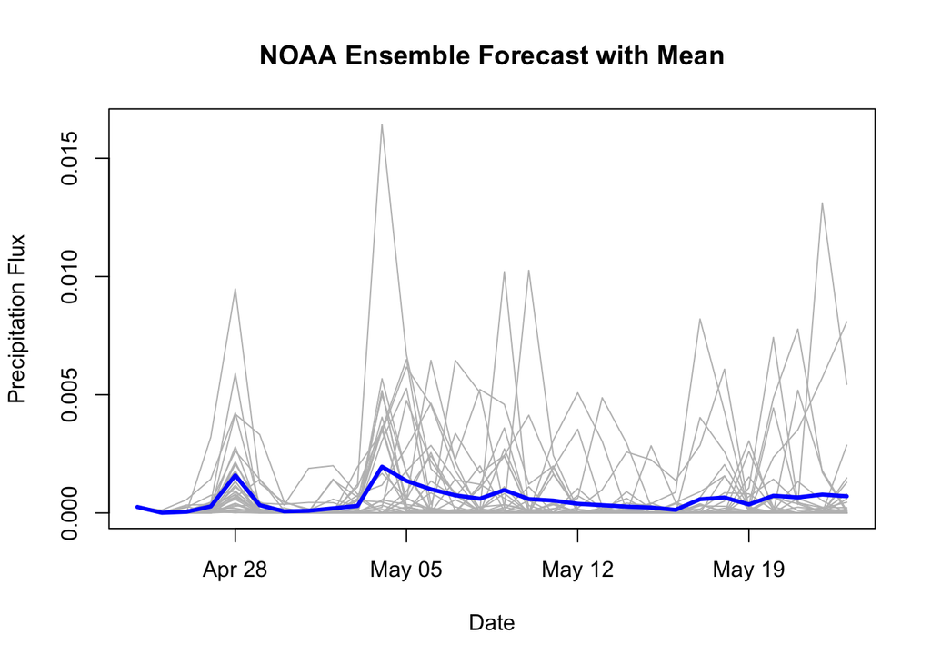

```r
# Filter down to just the 30 days we are forecasting for
precip_ens_forecast <- precip_ens_forecast %>%
  filter(date %in% forecast_dates)

plot(precip_ens_forecast$date,
     precip_ens_forecast$ens_0,
     type = 'l', col = "gray", ylim = range(precip_ens_forecast[ , grepl("ens_", names(precip_ens_forecast))], na.rm = TRUE),
     xlab = "Date", ylab = "Precipitation Flux", main = "NOAA Ensemble Forecast with Mean")

for(i in 0:30) {
  col_name <- paste0("ens_", i)
  lines(precip_ens_forecast$date,
        precip_ens_forecast[[col_name]],
        col = "gray")
}

lines(precip_ens_forecast$date, precip_ens_forecast$ens_mean, col = "blue", lwd = 3)
```

## Water Temperature

For water temperature, we will be using historical data for the dates being forecasted to create an ensemble forecast. So this will use the water temperature on the relevant dates for years 2019 to last year. The code below organizes these values into a data fram and then plots them with the mean forecast.

```r
## Set up data frame with historical ensemble

target_start <- forecast_dates[1]  #only month/day matter

# Step 1: Prepare the data with date components
temp_with_dates <- cleaned_data %>%
  mutate(date = as_date(datetime),
         year = year(date),
         doy = yday(date))

# Step 2: Loop over years and build the 30-day slices
years <- unique(temp_with_dates$year)

# Helper to extract 30-day windows for each year
get_30_day_window <- function(y) {
  start_date <- ymd(paste0(y, "-", month(target_start), "-", day(target_start)))
  end_date <- start_date + days(NT - 1)

  temp_with_dates %>%
    filter(date >= start_date & date <= end_date & year == y) %>%
    arrange(date) %>%
    mutate(day_index = row_number()) %>%
    select(year, day_index, temperature)
}

# Step 3: Combine all years
all_years_30d <- bind_rows(lapply(years, get_30_day_window))

# Step 4: Pivot to wide format, one column per year
temp_ensemble_df <- all_years_30d %>%
  pivot_wider(names_from = year, values_from = temperature, names_prefix = "yr_")


temp_ensemble_df$date <- forecast_dates

# If any years have no data at all, remove them
temp_ensemble_df <- temp_ensemble_df %>%
    select(where(~ !all(is.na(.))))

# Add a column with the mean forecast
temp_ensemble_df <- temp_ensemble_df %>%
  mutate(ens_mean = rowMeans(select(., starts_with("yr_")), na.rm = TRUE))
```

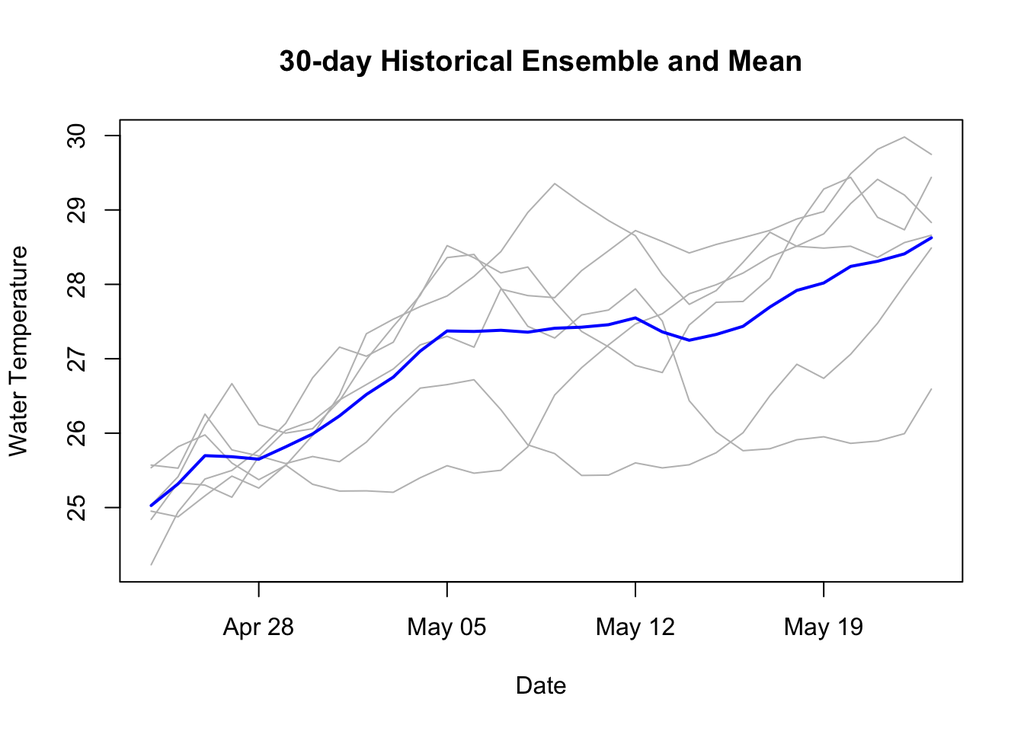

```r
ensemble_cols <- grep("^yr_", names(temp_ensemble_df), value = TRUE)

# Plot the first ensemble member to set up the plot
plot(temp_ensemble_df$date, temp_ensemble_df$ens_mean,
     type = "n", col = "grey", ylim = range(temp_ensemble_df[ ,ensemble_cols], na.rm = TRUE),
     xlab = "Date", ylab = "Water Temperature", main = "30-day Historical Ensemble and Mean")

# Loop through all ensemble member columns
for (col_name in ensemble_cols) {
  lines(temp_ensemble_df$date, temp_ensemble_df[[col_name]], col = "grey")
}

# Add the mean in blue
lines(temp_ensemble_df$date, temp_ensemble_df$ens_mean, col = "blue", lwd = 2)
```

# Ensemble Forecast and Uncertainty Analysis

Our forecast will involve four sources of uncertainty: initial conditions, parameter values, driver values, and process error.

## Set up

We first define a helper function that will generate ensemble forecasts.

```r
forecastN <- function(IC,
                      Nmc,
                      Betaintercept,
                      Betatemp,
                      Betaprecip,
                      BetaX,
                      temperature,
                      precipitation,
                      sd,
                      NT = 30){
  N <- matrix(NA,Nmc,NT)  ## storage
  Nprev <- IC           ## initialize

  for(tt in 1:NT){
    ## calculate mean
    mu = Nprev + Betaintercept + Betatemp*temperature[tt] + Betaprecip*precipitation[tt] + BetaX*Nprev
    N[,tt] <- rnorm(Nmc,mu, sd)                         ## predict next step
    Nprev <- N[,tt]                                  ## update IC
  }
  return(N)
}
```

```r
Nmc = 1000         ## set number of Monte Carlo draws
predict_matrix <- as.matrix(predict)

#sample rows from mcmc chain to run foreward in time
prow = sample.int(nrow(as.matrix(params)), Nmc, replace = TRUE)

## Set up parameters
param_matrix <- as.matrix(params)
param.mean <- apply(param_matrix,2,mean) # Find mean parameter values
```

## Initial Condition Uncertainty

```r
# Sample initial conditions
IC <- predict_matrix[prow, ncol(predict_matrix)]

N.ic <- forecastN(IC,
                Nmc,
                param.mean["betaIntercept"],
                param.mean["betatemp"],
                param.mean["betaprecip"],
                param.mean["betaX"],
                temp_ensemble_df$ens_mean,
                precip_ens_forecast$ens_mean,
                0)
```

## Parameter Uncertainty

```r
# Sample parameter values
Betatemp.sample <- param_matrix[prow, "betatemp"]
Betaprecip.sample <- param_matrix[prow, "betaprecip"]
BetaX.sample <- param_matrix[prow, "betaX"]
Betaintercept.sample <- param_matrix[prow, "betaIntercept"]


N.ic.p <- forecastN(IC,
                Nmc,
                Betaintercept.sample,
                Betatemp.sample,
                Betaprecip.sample,
                BetaX.sample,
                temp_ensemble_df$ens_mean,
                precip_ens_forecast$ens_mean,
                0)
```

## Driver Uncertainty

```r
## Sample driver columns with replacement

# Turn temperature forecast ensemble tibble into a matrix
temp_ens_matrix <- temp_ensemble_df %>%
  select(starts_with("yr_")) %>%
  as.matrix()
temp_cols <- sample.int(ncol(temp_ens_matrix),Nmc,replace=TRUE) # sample

# Turn precipitation forecast ensemble tibble into a matrix
precip_ens_matrix <- precip_ens_forecast %>%
  select(starts_with("ens_") & !ends_with("mean")) %>%
  as.matrix()
precip_cols <- sample.int(ncol(precip_ens_matrix),Nmc,replace=TRUE)

N.ic.p.d <- forecastN(IC,
                Nmc,
                Betaintercept.sample,
                Betatemp.sample,
                Betaprecip.sample,
                BetaX.sample,
                temp_ens_matrix[ , temp_cols],
                precip_ens_matrix[ , precip_cols],
                0)
```

## Process Uncertainty

```r
tau_add.sample <- param_matrix[prow, "tau_add"]
sd.sample <- 1/sqrt(tau_add.sample)

N.ic.p.d.pr <- forecastN(IC,
                Nmc,
                Betaintercept.sample,
                Betatemp.sample,
                Betaprecip.sample,
                BetaX.sample,
                temp_ens_matrix[ , temp_cols],
                precip_ens_matrix[ , precip_cols],
                sd.sample)
```

# Plotted Ensemble Forecast with Partitioned Uncertainty

```r
## you can adjust this line to zoom in and out on specific time intervals
time.rng = c(2600,nrow(cleaned_data)+30)

## You can adjust this line to adjust the y-axis zoom
y.rng <- range(cleaned_data$chla,na.rm=TRUE)
#y.rng <- c(0,5)


## Plot historical fit data
out <- predict_matrix
ci <- apply(out,2,quantile,c(0.025,0.5,0.975))

# Time interval set up
dates <-  as.Date(cleaned_data$datetime)
dates <- c(dates, seq.Date(from = tail(dates, 1) + 1, by = "day", length.out = 30))
```

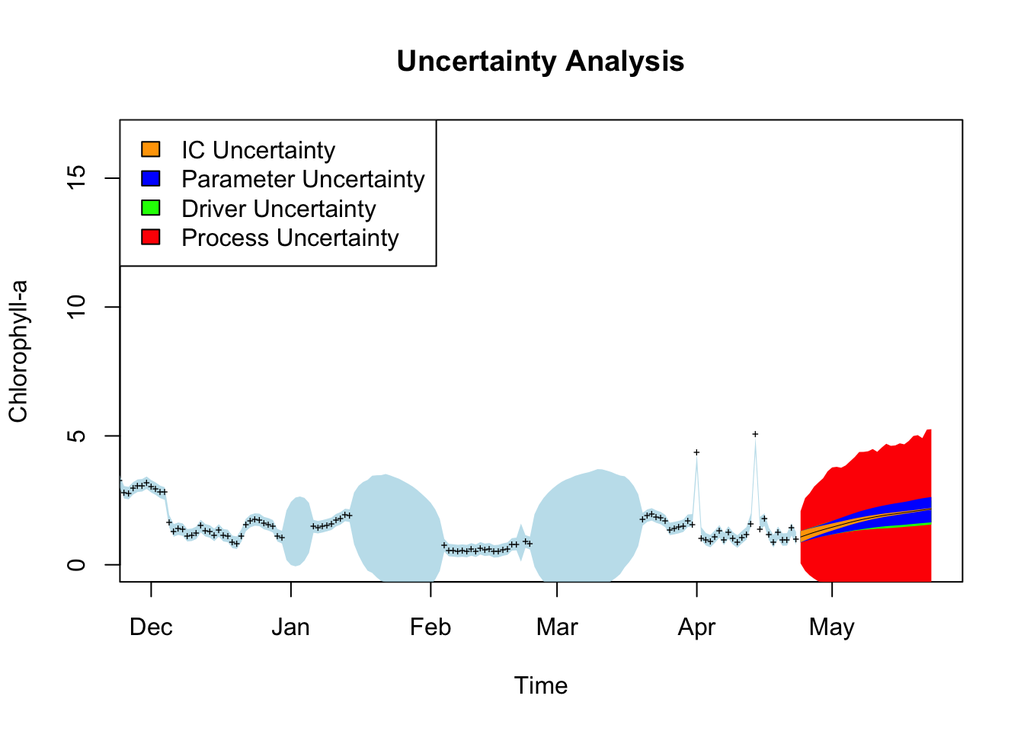

```r
plot(dates, 1:length(dates) ,type='n',
     ylim = y.rng,
     #log='y',
     xlim=dates[time.rng],
     xlab = "Time",
     ylab = "Chlorophyll-a",
     main = "Uncertainty Analysis")
## adjust x-axis label to be monthly if zoomed
#if(diff(time.rng) < 100){
#  axis.Date(1, at=seq(cleaned_data$datetime[time.rng[1]],cleaned_data$datetime[time.rng[2]],by='month'), format = "%Y-%m")
#}
ecoforecastR::ciEnvelope(as.Date(cleaned_data$datetime),ci[1,],ci[3,],col=ecoforecastR::col.alpha("lightBlue",0.75))
points(as.Date(cleaned_data$datetime), cleaned_data$chla,pch="+",cex=0.5)




## Add forecast and uncertainties
N.ic.ci = apply(N.ic,2,quantile,c(0.025,0.5,0.975))
N.ic.p.ci = apply(N.ic.p,2,quantile,c(0.025,0.5,0.975))
N.ic.p.d.ci = apply(N.ic.p.d,2,quantile,c(0.025,0.5,0.975))
N.ic.p.d.pr.ci = apply(N.ic.p.d.pr,2,quantile,c(0.025,0.5,0.975))

N.cols <- c("orange", "blue", "green", "red")

ecoforecastR::ciEnvelope(tail(dates, 30),N.ic.p.d.pr.ci[1,],N.ic.p.d.pr.ci[3,],col= N.cols[4]) # Process
ecoforecastR::ciEnvelope(tail(dates, 30),N.ic.p.d.ci[1,],N.ic.p.d.ci[3,],col= N.cols[3]) # Driver
ecoforecastR::ciEnvelope(tail(dates, 30),N.ic.p.ci[1,],N.ic.p.ci[3,],col= N.cols[2]) # Paramater
ecoforecastR::ciEnvelope(tail(dates, 30),N.ic.ci[1,],N.ic.ci[3,],col= N.cols[1]) # Init Cond


lines(tail(dates, 30),N.ic.ci[2,],lwd=0.5)

legend("topleft", legend = c("IC Uncertainty", "Parameter Uncertainty", "Driver Uncertainty", "Process Uncertainty"), fill =  N.cols)
```

## Ensemble Forecast in Context

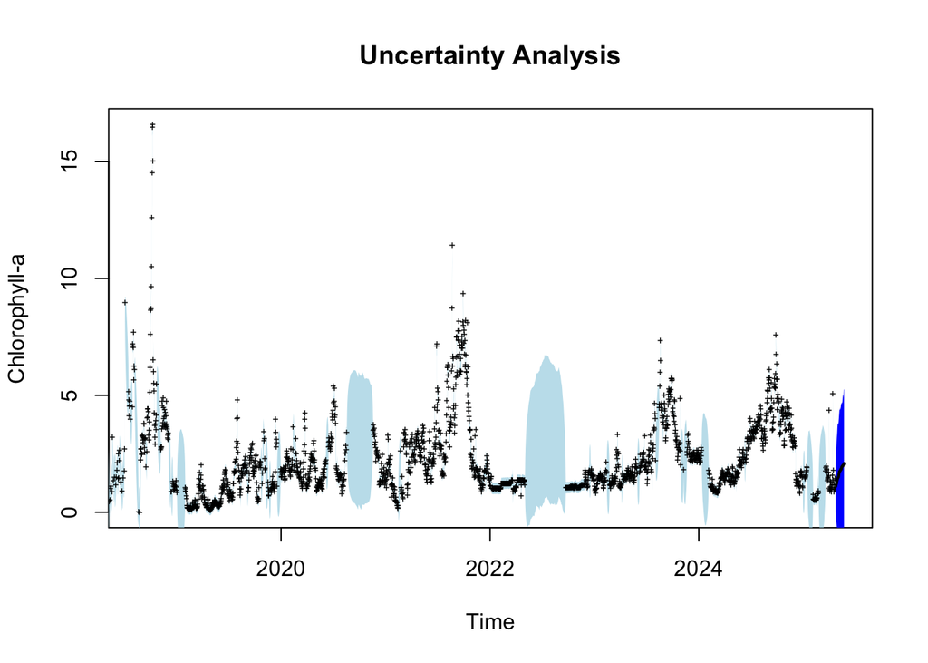

```r
## you can adjust this line to zoom in and out on specific time intervals
time.rng = c(300,nrow(cleaned_data)+30)

plot(dates, 1:length(dates) ,type='n',
     ylim = y.rng,
     #log='y',
     xlim=dates[time.rng],
     xlab = "Time",
     ylab = "Chlorophyll-a",
     main = "Uncertainty Analysis")
## adjust x-axis label to be monthly if zoomed
#if(diff(time.rng) < 100){
#  axis.Date(1, at=seq(cleaned_data$datetime[time.rng[1]],cleaned_data$datetime[time.rng[2]],by='month'), format = "%Y-%m")
#}
ecoforecastR::ciEnvelope(as.Date(cleaned_data$datetime),ci[1,],ci[3,],col=ecoforecastR::col.alpha("lightBlue",0.75))
points(as.Date(cleaned_data$datetime), cleaned_data$chla,pch="+",cex=0.5)

# Add forecast
ecoforecastR::ciEnvelope(tail(dates, 30),N.ic.p.d.pr.ci[1,],N.ic.p.d.pr.ci[3,],col= "blue") # Process
lines(tail(dates, 30),N.ic.p.d.pr.ci[2,],lwd=2)
```

# Relative Variance

Next, we found the variances of each forecast generated in the first part of the uncertainty analysis. This allows us to look at the relative variance introduced by each source of uncertainty, and how that changes over time. It is clear that for all time, process error is dominating our forecast.

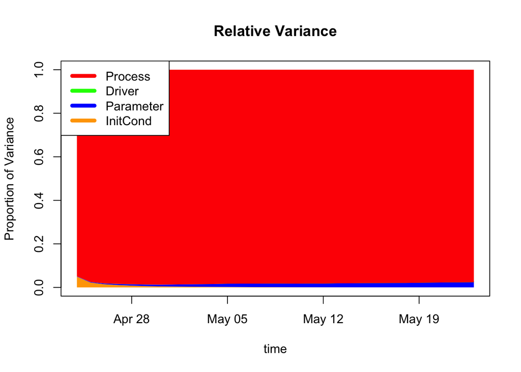

```r
### calculation of variances
varI     <- apply(N.ic,2,var)
varIP    <- apply(N.ic.p,2,var)
varIPD   <- apply(N.ic.p.d,2,var)
varIPDPR  <- apply(N.ic.p.d.pr,2,var)
varMat   <- rbind(varI,varIP,varIPD,varIPDPR)


## in-sample stacked area plot
V.pred.rel.in <- apply(varMat,2,function(x) {x/max(x)})
plot(forecast_dates,V.pred.rel.in[1,],ylim=c(0,1),type='n',main="Relative Variance",ylab="Proportion of Variance",xlab="time")
ciEnvelope(forecast_dates,rep(0,ncol(V.pred.rel.in)),V.pred.rel.in[1,],col=N.cols[1])
ciEnvelope(forecast_dates,V.pred.rel.in[1,],V.pred.rel.in[2,],col=N.cols[2])
ciEnvelope(forecast_dates,V.pred.rel.in[2,],V.pred.rel.in[3,],col=N.cols[3])
ciEnvelope(forecast_dates,V.pred.rel.in[3,],V.pred.rel.in[4,],col=N.cols[4])
legend("topleft",legend=c("Process","Driver","Parameter","InitCond"),col=rev(N.cols),lty=1,lwd=5)
```